# NLSY Parent Income and Wealth Imputation

# Data Summary

Table 1: Data summary, continuous variables

|  | Unique (#) | Missing (%) | Mean | SD | Min | Median | Max |  |
| --- | --- | --- | --- | --- | --- | --- | --- | --- |
| age_resp | 5 | 0 | 14.0 | 1.4 | 12.0 | 14.0 | 16.0 |  |
| bdate_y | 5 | 0 | 1982.0 | 1.4 | 1980.0 | 1982.0 | 1984.0 |  |
| pincome | 2234 | 27 | 46483.5 | 42112.7 | 0.0 | 37900.0 | 246474.0 |  |
| pnetworth | 2507 | 26 | 90429.7 | 137578.8 | −935251.0 | 34500.0 | 600000.0 |  |
| retsav1 | 228 | 75 | 44237.2 | 63017.9 | 0.0 | 20000.0 | 300000.0 |  |
| mom_age_birth | 31 | 7 | 25.5 | 5.4 | 16.0 | 25.0 | 45.0 |  |
| mom_age | 35 | 7 | 39.5 | 5.5 | 28.0 | 39.0 | 61.0 |  |
| has_retsav | 3 | 13 | 0.5 | 0.5 | 0.0 | 0.0 | 1.0 |  |
| owns_home | 3 | 18 | 0.6 | 0.5 | 0.0 | 1.0 | 1.0 |  |
| both_parents | 2 | 0 | 0.5 | 0.5 | 0.0 | 0.0 | 1.0 |  |

Table 2: Data summary, categorical variables

|  |  | N | % |
| --- | --- | --- | --- |
| mom_educ_hs | Less than high school | 1779 | 20.0 |
|  | High-school graduate | 2860 | 32.1 |
|  | Some college | 1877 | 21.1 |
|  | College degree | 1057 | 11.9 |
|  | Graduate degree | 284 | 3.2 |
| dad_educ_hs | Less than high school | 1142 | 12.8 |
|  | High-school graduate | 1913 | 21.5 |
|  | Some college | 1224 | 13.8 |
|  | College degree | 894 | 10.0 |
|  | Graduate degree | 338 | 3.8 |
| race_eth | AAPI Hispanic | 4 | 0.0 |
|  | AAPI NonHispanic | 156 | 1.8 |
|  | AIAN Hispanic | 18 | 0.2 |
|  | AIAN NonHispanic | 43 | 0.5 |
|  | Black Hispanic | 54 | 0.6 |
|  | Black NonHispanic | 2333 | 26.2 |
|  | Other Race Hispanic | 944 | 10.6 |
|  | Other Race NonHispanic | 119 | 1.3 |
|  | White Hispanic | 819 | 9.2 |
|  | White NonHispanic | 4406 | 49.5 |

# Imputation of Parental Income and Networth

## Choices

From `mice` package documentation:

1. First, we should decide whether the missing at random (MAR) assumption (Rubin 1976) is plausible. The MAR assumption is a suitable starting point in many practical cases, but there are also cases where the assumption is suspect. Schafer (1997, pp. 20–23) provides a good set of practical examples. MICE can handle both MAR and missing not at random (MNAR). Multiple imputation under MNAR requires additional modeling assumptions that influence the generated imputations. There are many ways to do this. We refer to Section 6.2 for an example of how that could be realized.
2. The second choice refers to the form of the imputation model. The form encompasses both the structural part and the assumed error distribution. Within MICE the form needs to be specified for each incomplete column in the data. The choice will be steered by the scale of the dependent variable (i.e., the variable to be imputed), and preferably incorporates knowledge about the relation between the variables. Section 3.2 describes the possibilities within mice 2.9.
3. Our third choice concerns the set of variables to include as predictors into the imputation model. The general advice is to include as many relevant variables as possible including their interactions (Collins et al. 2001). This may however lead to unwieldy model specifications that could easily get out of hand. Section 3.3 describes the facilities within mice 2.9 for selecting the predictor set.
4. The fourth choice is whether we should impute variables that are functions of other (incomplete) variables. Many data sets contain transformed variables, sum scores, interaction variables, ratios, and so on. It can be useful to incorporate the transformed variables into the multiple imputation algorithm. Section 3.4 describes how mice 2.9 deals with this situation using passive imputation.
5. The fifth choice concerns the order in which variables should be imputed. Several strategies are possible, each with their respective pro’s and cons. Section 3.6 shows how the visitation scheme of the MICE algorithm within mice 2.9 is under control of the user
6. The sixth choice concerns the setup of the starting imputations and the number of iterations. The convergence of the MICE algorithm can be monitored in many ways. Section 4.3 outlines some techniques in mice 2.9 that assist in this task.
7. The seventh choice is m, the number of multiply imputed data sets. Setting m too low may result in large simulation error, especially if the fraction of missing information is high.

## Significance of Predictors

Table 3: Regression of pincome to examine significance of predictors

|  | pincome | pnetworth |
| --- | --- | --- |
| (Intercept) | 67843.438*** | −1589.162 |
| mom_age | 765.726*** | 4276.303*** |
| race_ethAAPI NonHispanic | −45621.940** | −57439.825 |
| race_ethAIAN Hispanic | −71898.806* | −135081.226 |
| race_ethAIAN NonHispanic | −50782.647** | −134459.990* |
| race_ethBlack Hispanic | −66498.424*** | −169547.969** |
| race_ethBlack NonHispanic | −54745.115*** | −152405.027** |
| race_ethOther Race Hispanic | −52600.891*** | −118811.326 |
| race_ethOther Race NonHispanic | −56368.568*** | −105934.771 |
| race_ethWhite Hispanic | −55943.174*** | −144242.355** |
| race_ethWhite NonHispanic | −47277.084** | −99882.141 |
| mom_educ_hs.L | 22019.499*** | 71591.805*** |
| mom_educ_hs.Q | 6059.871*** | 23474.098*** |
| mom_educ_hs.C | 1107.549 | −615.634 |
| mom_educ_hs^4 | −2121.900 | −14018.565*** |
| dad_educ_hs.L | 26076.534*** | 60049.340*** |
| dad_educ_hs.Q | 1673.669 | 12633.649* |
| dad_educ_hs.C | 1146.181 | 7439.006 |
| dad_educ_hs^4 | −357.175 | −4198.144 |
| has_retsav | 16538.399*** | 44285.502*** |
| owns_home | 12387.903*** | 68008.452*** |
| both_parents | −1833.451 | 21864.080*** |
| par_dec | −2769.377 | 14312.449 |
| Num.Obs. | 2973 | 2973 |
| R2 | 0.324 | 0.314 |
| R2 Adj. | 0.319 | 0.309 |
| AIC | 70546.8 | 78287.6 |
| BIC | 70690.7 | 78431.5 |
| Log.Lik. | −35249.385 | −39119.783 |
| F | 64.307 | 61.428 |
| RMSE | 34117.48 | 125418.88 |

### Checking for multi-collinearity - correlation plot for numeric variables

```
                 age_resp   mom_age  has_retsav  owns_home both_parents
age_resp      1.000000000 0.2115985 0.007221412 0.02020203   -0.0336063
mom_age       0.211598517 1.0000000 0.155942508 0.20824653    0.2347601
has_retsav    0.007221412 0.1559425 1.000000000 0.41849655    0.2698076
owns_home     0.020202029 0.2082465 0.418496546 1.00000000    0.3737127
both_parents -0.033606299 0.2347601 0.269807569 0.37371271    1.0000000
```

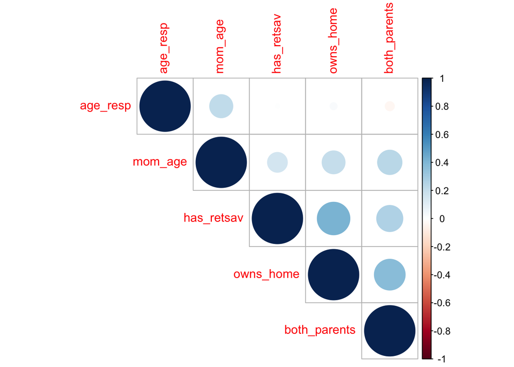

## Checking for missings in the predictor variables

```
          id      pincome    pnetworth      mom_age  mom_educ_hs  dad_educ_hs
           0         2361         2327          593         1039         3385
    race_eth   has_retsav    owns_home both_parents
           0         1158         1583            0
```

```
              id pincome pnetworth mom_age mom_educ_hs dad_educ_hs race_eth
id           NaN     NaN       NaN     NaN         NaN         NaN      NaN
pincome        1   0.000     0.330   0.903       0.839       0.579        1
pnetworth      1   0.320     0.000   0.903       0.837       0.651        1
mom_age        1   0.614     0.619   0.000       0.671       0.540        1
mom_educ_hs    1   0.633     0.635   0.812       0.000       0.363        1
dad_educ_hs    1   0.706     0.760   0.919       0.804       0.000        1
race_eth     NaN     NaN       NaN     NaN         NaN         NaN      NaN
has_retsav     1   0.068     0.000   0.872       0.788       0.603        1
owns_home      1   0.340     0.303   0.896       0.817       0.587        1
both_parents NaN     NaN       NaN     NaN         NaN         NaN      NaN
             has_retsav owns_home both_parents
id                  NaN       NaN          NaN
pincome           0.543     0.557            1
pnetworth         0.502     0.526            1
mom_age           0.750     0.722            1
mom_educ_hs       0.763     0.721            1
dad_educ_hs       0.864     0.807            1
race_eth            NaN       NaN          NaN
has_retsav        0.000     0.105            1
owns_home         0.346     0.000            1
both_parents        NaN       NaN          NaN
```

## Checking for MCAR

The two pairs of boxplots on the edges of Figure 1 show distributions of pincome and pwealth when the other variable is present and when it’s missing. Variable pnetworth has somewhat lower mean in the subsample where pincome is missing than in the subsample where pincome is present. The distribution of pincome in the subsample where pnetworth is missing is shifted upward relative to its distribution in the subsample where pnetworth is present. In each case, these distributions are relatively similar, and the MCAR assumption is not implausible.

Figure 1: Marginal plot for parental income and wealth

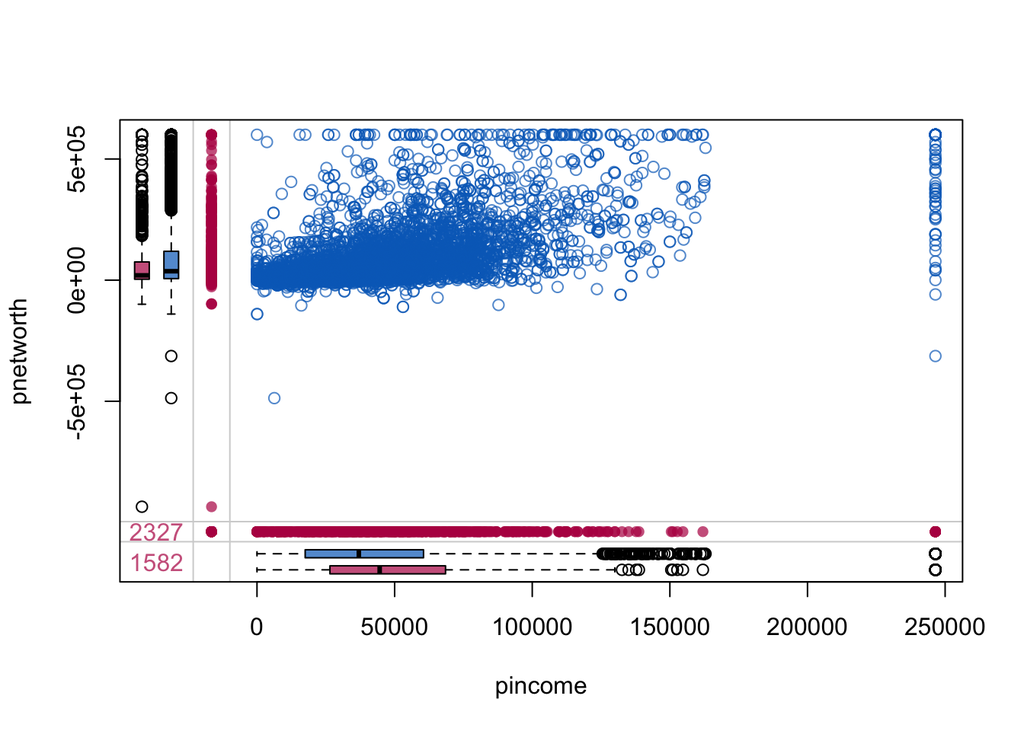

## Multiple Imputation of Parental Income and Networth

Table 4: Imputation-methods vector

|  | x |
| --- | --- |
| id |  |
| pincome | pmm |
| pnetworth | pmm |
| mom_age | pmm |
| mom_educ_hs | polr |
| dad_educ_hs | polr |
| race_eth |  |
| has_retsav | logreg |
| owns_home | logreg |
| both_parents |  |

Table 5: Imputation predictor matrix

|  | id | pincome | pnetworth | mom_age | mom_educ_hs | dad_educ_hs | race_eth | has_retsav | owns_home | both_parents |
| --- | --- | --- | --- | --- | --- | --- | --- | --- | --- | --- |
| id | 0 | 1 | 1 | 1 | 1 | 1 | 1 | 1 | 1 | 1 |
| pincome | 0 | 0 | 1 | 1 | 1 | 1 | 1 | 1 | 1 | 1 |
| pnetworth | 0 | 1 | 0 | 1 | 1 | 1 | 1 | 1 | 1 | 1 |
| mom_age | 0 | 1 | 1 | 0 | 1 | 1 | 1 | 1 | 1 | 1 |
| mom_educ_hs | 0 | 1 | 1 | 1 | 0 | 1 | 1 | 1 | 1 | 1 |
| dad_educ_hs | 0 | 1 | 1 | 1 | 1 | 0 | 1 | 1 | 1 | 1 |
| race_eth | 0 | 1 | 1 | 1 | 1 | 1 | 1 | 1 | 1 | 1 |
| has_retsav | 0 | 1 | 1 | 1 | 1 | 1 | 1 | 0 | 1 | 1 |
| owns_home | 0 | 1 | 1 | 1 | 1 | 1 | 1 | 1 | 0 | 1 |
| both_parents | 0 | 1 | 1 | 1 | 1 | 1 | 1 | 1 | 1 | 0 |

## Distribution Plots for Parent Income (non-imputed and imputed)

Figure 2: Distribution of parental income, original and imputed

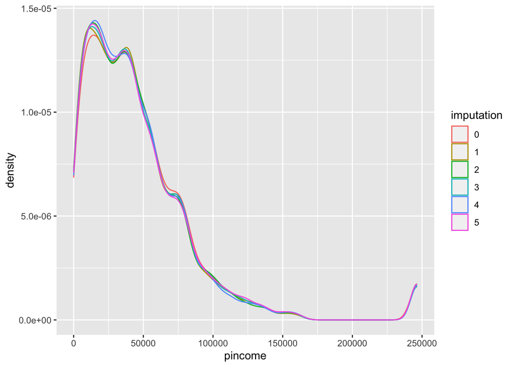

Figure 3: Distribution of parental income by race, original and imputed

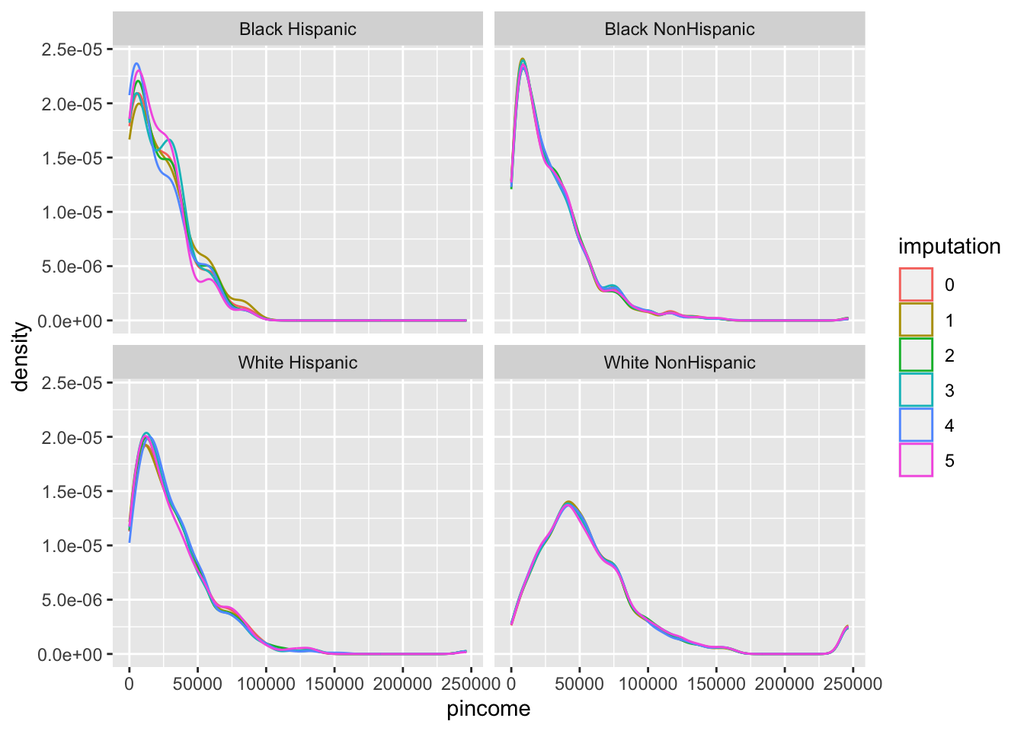

## Distribution Plots for Parent Wealth (non-imputed and imputed)

Figure 4: Distribution of parental net worth, original and imputed

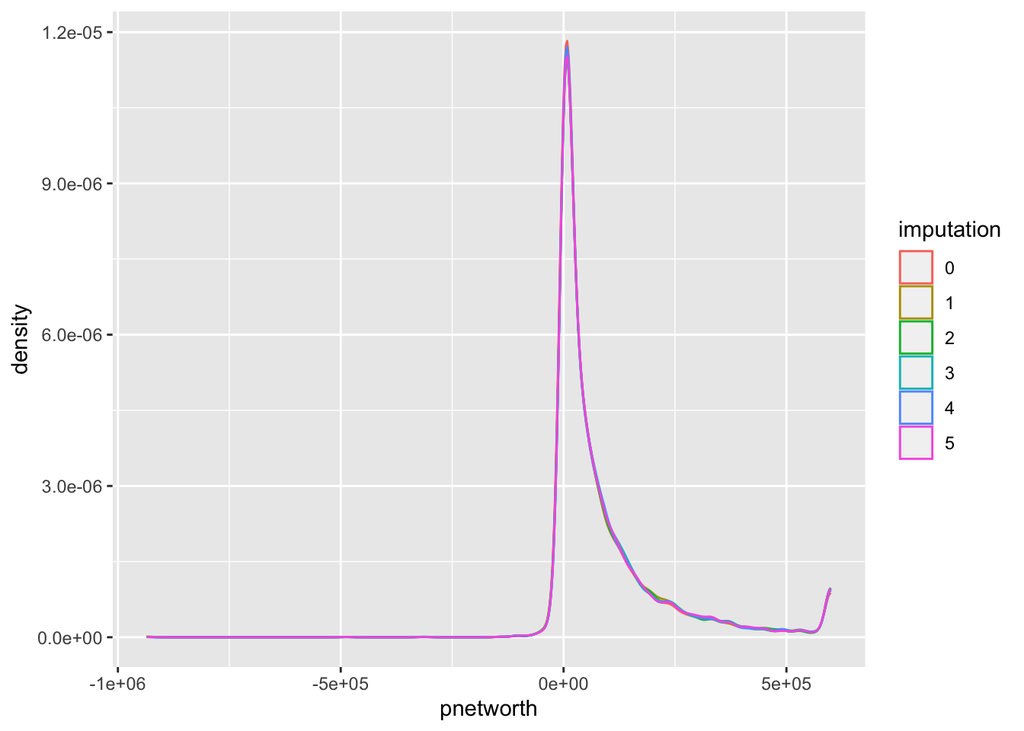

Figure 5: Distribution of parental net worth by race, original and imputed

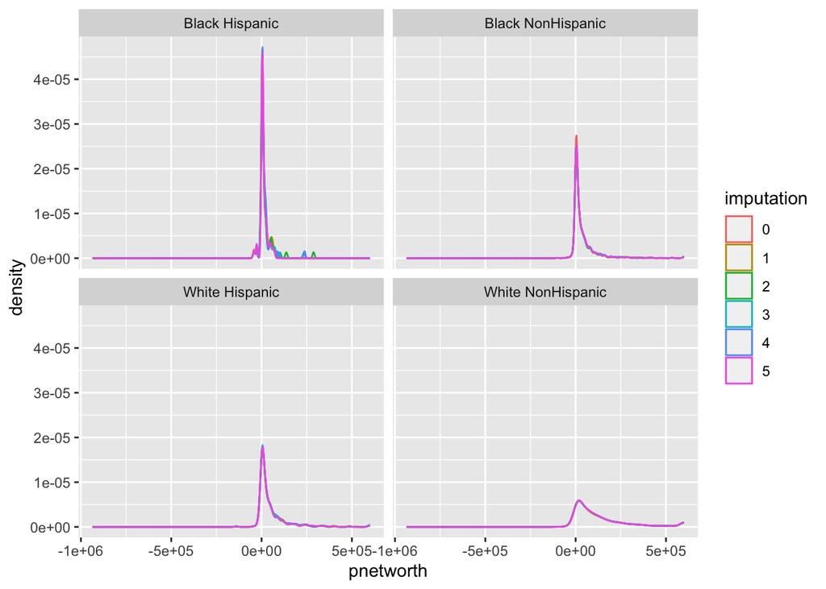

## Distribution Plots for Dad Education (non-imputed and imputed)

Table 6: Total number of observations and number of missing values of father’s education by race and ethnicity

| race_eth | N | dad_educ_miss |
| --- | --- | --- |
| AAPI Hispanic | 4 | 1 |
| AAPI NonHispanic | 156 | 37 |
| AIAN Hispanic | 18 | 16 |
| AIAN NonHispanic | 43 | 14 |
| Black Hispanic | 54 | 31 |
| Black NonHispanic | 2333 | 1411 |
| Other Race Hispanic | 944 | 398 |
| Other Race NonHispanic | 119 | 43 |
| White Hispanic | 819 | 303 |
| White NonHispanic | 4406 | 1131 |

Figure 6: Shares of father’s educational attainment for the original and imputed data

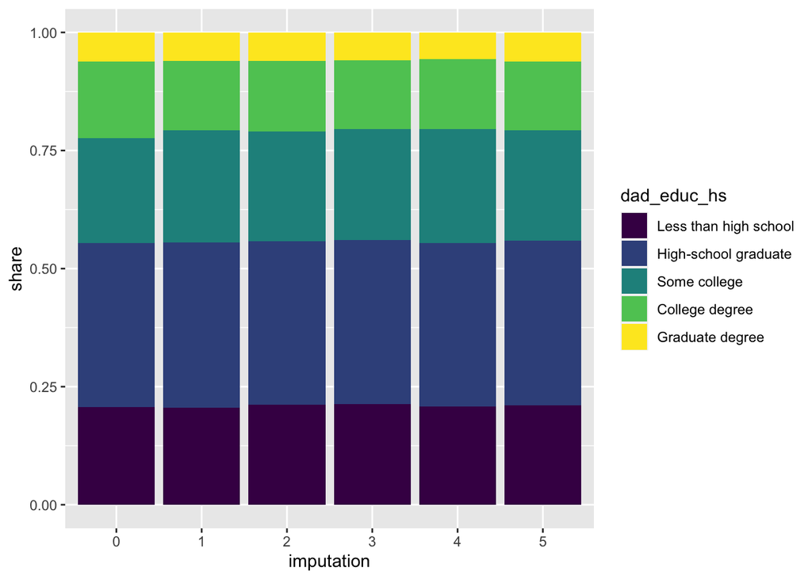

Figure 7: Shares of father’s educational attainment for the original and imputed data by race and ethnicity

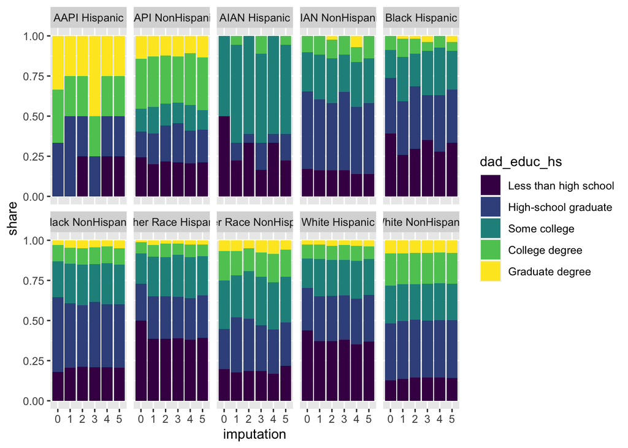

## Whisker Plots

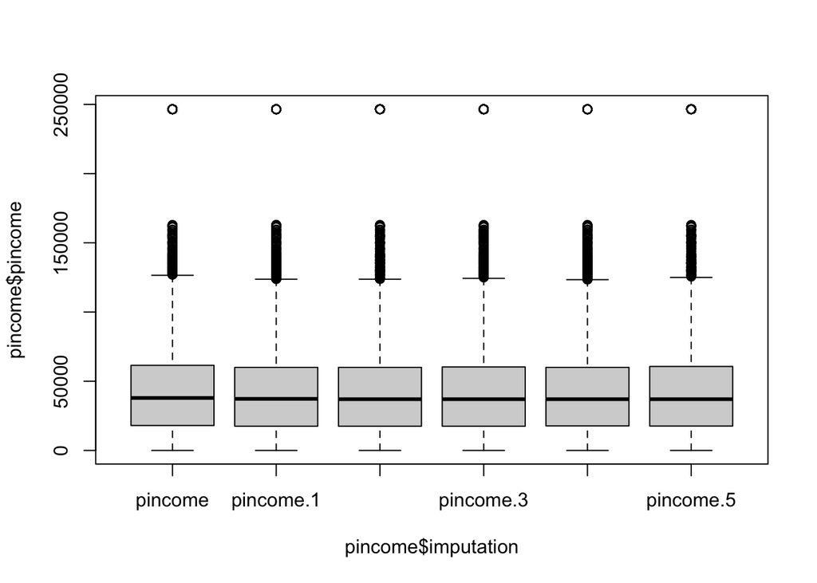

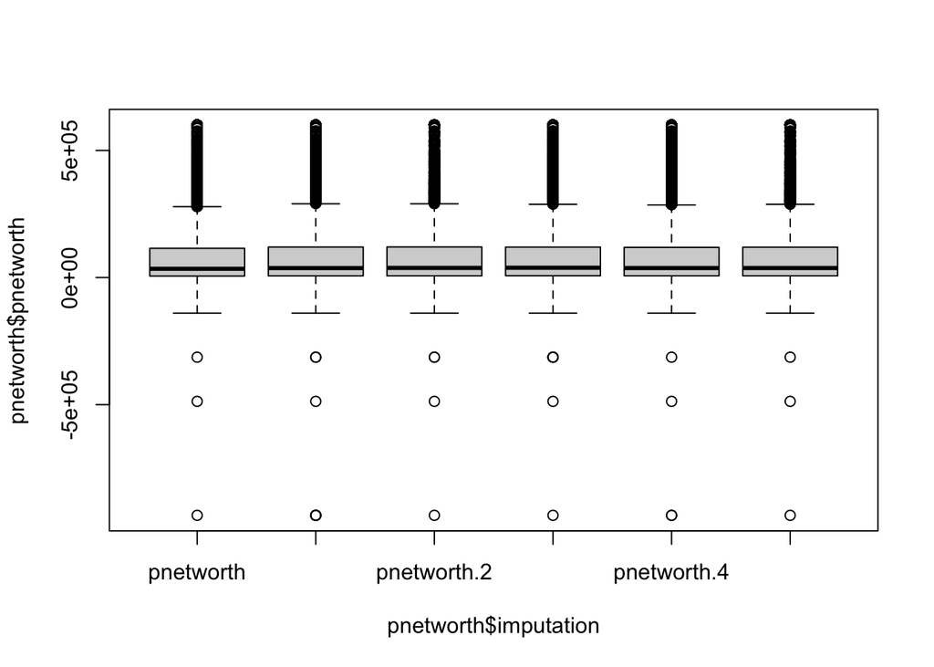

## Scatter Plots for both parent income and wealth (non-imputed is zero)

Figure 8: Scatterplots of parental income and networth, original and imputed

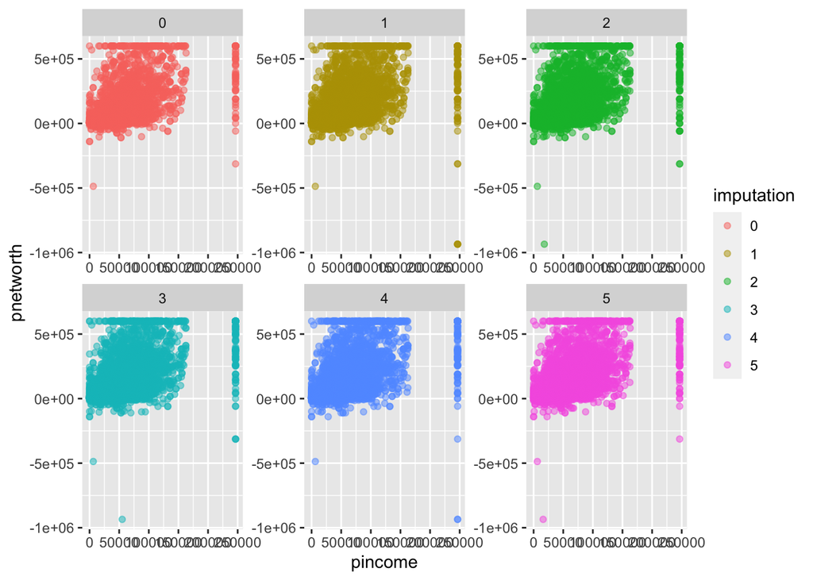

# Imputation of Retirement Savings

Table 7: Methods vector for the imputation of retirement savings

|  | x |
| --- | --- |
| id |  |
| pincome |  |
| pnetworth |  |
| mom_age |  |
| mom_educ_hs |  |
| dad_educ_hs |  |
| race_eth |  |
| has_retsav |  |
| owns_home |  |
| both_parents |  |
| retsav | pmm |

Table 8: Predictor matrix for the imputation of retirement savings

|  | id | pincome | pnetworth | mom_age | mom_educ_hs | dad_educ_hs | race_eth | has_retsav | owns_home | both_parents | retsav |
| --- | --- | --- | --- | --- | --- | --- | --- | --- | --- | --- | --- |
| id | 0 | 1 | 1 | 1 | 1 | 1 | 1 | 0 | 1 | 1 | 1 |
| pincome | 0 | 0 | 1 | 1 | 1 | 1 | 1 | 0 | 1 | 1 | 1 |
| pnetworth | 0 | 1 | 0 | 1 | 1 | 1 | 1 | 0 | 1 | 1 | 1 |
| mom_age | 0 | 1 | 1 | 0 | 1 | 1 | 1 | 0 | 1 | 1 | 1 |
| mom_educ_hs | 0 | 1 | 1 | 1 | 0 | 1 | 1 | 0 | 1 | 1 | 1 |
| dad_educ_hs | 0 | 1 | 1 | 1 | 1 | 0 | 1 | 0 | 1 | 1 | 1 |
| race_eth | 0 | 1 | 1 | 1 | 1 | 1 | 1 | 0 | 1 | 1 | 1 |
| has_retsav | 0 | 1 | 1 | 1 | 1 | 1 | 1 | 0 | 1 | 1 | 1 |
| owns_home | 0 | 1 | 1 | 1 | 1 | 1 | 1 | 0 | 0 | 1 | 1 |
| both_parents | 0 | 1 | 1 | 1 | 1 | 1 | 1 | 0 | 1 | 0 | 1 |
| retsav | 0 | 1 | 1 | 1 | 1 | 1 | 1 | 0 | 1 | 1 | 0 |

## Distribution Plots for Retirement Savings (non-imputed and imputed)

Figure 9: Distribution of parental retirement savings, original and imputed

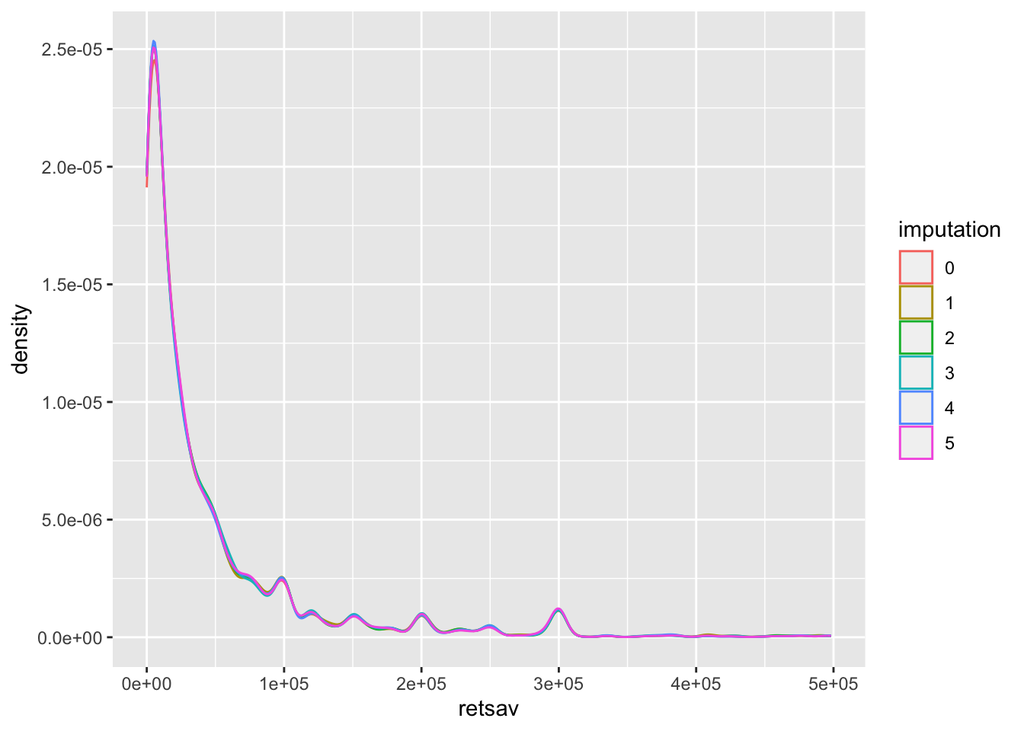

Figure 10: Distribution of parental retirement savings by race, original and imputed

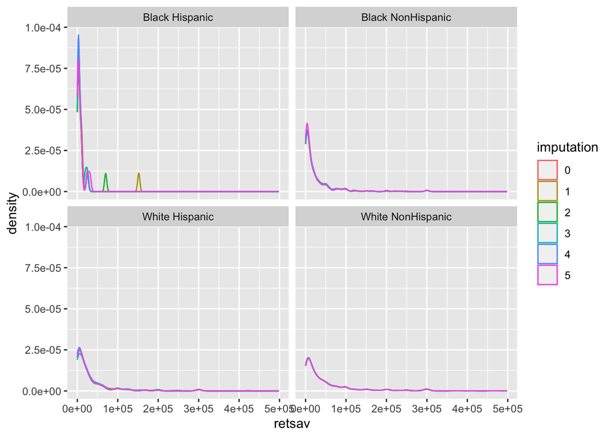

Figure 11: Scatterplots of parental retirement savings and networth, original and imputed

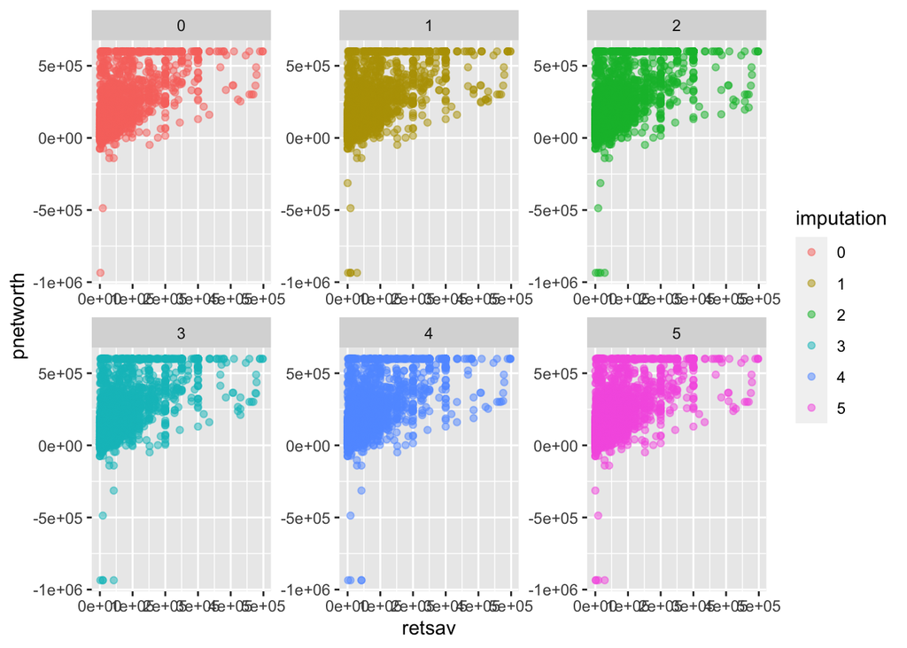